# Mutual Funds SVM with Pyspark

```python
import findspark
findspark.init()
```

```python
from pyspark import SparkContext, SparkConf
from pyspark.sql import SQLContext
conf = SparkConf().setAppName('Mnist_Spark_MLP').set('spark.executor.memory', '8g').set('spark.driver.memory', '4g').setMaster('local[8]')
sc = SparkContext(conf=conf)
sqlContext = SQLContext(sc)
```

```python
import pandas as pd
import numpy as np
from matplotlib import pyplot as plt
import seaborn as sns
import warnings
warnings.filterwarnings("ignore")
%autosave 0
```

```
Autosave disabled
```

```python
df = sqlContext.read.csv('C:/Users/fcont/Desktop/MBA/Machine Learning/mutual_funds.csv',
                        header=True, inferSchema=True)
df.show(5)
```

```
+---------+--------------------+--------------------+--------------------+----------+----------+----------+------------------+--------------+----------+-----+--------+-----------------------------+---------------------------------+--------------+----------------+---------------+----------------+----…
|fund_name|  fund_extended_name|            category|         fund_family|net_assets|ytd_return|fund_yield|morningstar_rating|inception_date|investment| size|currency|net_annual_expense_ratio_fund|net_annual_expense_ratio_category|portfolio_cash|portfolio_stocks|portfolio_bonds|portfolio_others|port…
+---------+--------------------+--------------------+--------------------+----------+----------+----------+------------------+--------------+----------+-----+--------+-----------------------------+---------------------------------+--------------+----------------+---------------+----------------+----…
|    AAAAX|DWS RREEF Real As...|    World Allocation|                 DWS| 530280000|     12.79|      1.43|                 3|     7/29/2007|     Blend|Large|     USD|                         1.22|                             1.01|           3.8|           76.25|          15.35|             4.6|    …
|    AAADX|Aberdeen Income B...|         Large Blend|            Aberdeen|  88840000|      9.21|      2.62|                 2|    12/29/2011|     Blend|Large|     USD|                         1.43|                             0.94|          1.97|           47.13|          49.75|             0.0|    …
|    AAAGX|Thrivent Large Ca...|        Large Growth|      Thrivent Funds|1080000000|      16.0|       0.0|                 3|    10/28/1999|    Growth|Large|     USD|                         1.15|                             1.06|          1.91|           97.06|            0.0|            1.03|    …
|    AAAIX|American Century ...|Allocation - 70% ...|American Century ...| 785270000|     11.57|      1.38|                 4|     7/31/2000|    Growth|Large|     USD|                         0.91|                             0.77|          2.57|           75.06|          22.29|            0.04|    …
|    AAANX|Horizon Active As...| Tactical Allocation| Horizon Investments| 527130000|     11.62|      0.66|                 4|     1/30/2012|     Blend|Large|     USD|                         1.44|                             1.38|          4.27|           95.71|            0.0|            0.01|    …
+---------+--------------------+--------------------+--------------------+----------+----------+----------+------------------+--------------+----------+-----+--------+-----------------------------+---------------------------------+--------------+----------------+---------------+----------------+----…
only showing top 5 rows
```

*** A Cleaner way to see the data

```python
from pyspark.sql import SparkSession
spark = SparkSession.builder.getOrCreate()
spark.conf.set("spark.sql.repl.eagerEval.enabled", True)

df.limit(5)
```

| fund_name | fund_extended_name | category | fund_family | net_assets | ytd_return | fund_yield | morningstar_rating | inception_date | investment | size | currency | net_annual_expense_ratio_fund | net_annual_expense_ratio_category | portfolio_cash | portfolio_stocks | portfolio_bonds | portfolio_others | portfolio_preferred | portfolio_convertable | price_earnings | price_book | price_sales | price_cashflow | median_market_cap | basic_materials | consumer_cyclical | financial_services | real_estate | consumer_defensive | … |
| --- | --- | --- | --- | --- | --- | --- | --- | --- | --- | --- | --- | --- | --- | --- | --- | --- | --- | --- | --- | --- | --- | --- | --- | --- | --- | --- | --- | --- | --- | --- |
| AAAAX | DWS RREEF Real As... | World Allocation | DWS | 530280000 | 12.79 | 1.43 | 3 | 7/29/2007 | Blend | Large | USD | 1.22 | 1.01 | 3.8 | 76.25 | 15.35 | 4.6 | 0.0 | 0.0 | 21.58 | 1.93 | 2.32 | 9.81 | 14,247.52 | 7.48 | 0.16 | 0.0 | 39.52 | 0.93 | … |
| AAADX | Aberdeen Income B... | Large Blend | Aberdeen | 88840000 | 9.21 | 2.62 | 2 | 12/29/2011 | Blend | Large | USD | 1.43 | 0.94 | 1.97 | 47.13 | 49.75 | 0.0 | 1.14 | 0.0 | 11.76 | 2.94 | 2.81 | 13.6 | 147,673.66 | 0.0 | 4.78 | 17.68 | 1.15 | 5.7 | … |
| AAAGX | Thrivent Large Ca... | Large Growth | Thrivent Funds | 1080000000 | 16.0 | 0.0 | 3 | 10/28/1999 | Growth | Large | USD | 1.15 | 1.06 | 1.91 | 97.06 | 0.0 | 1.03 | 0.0 | 0.0 | 24.49 | 5.78 | 4.45 | 14.29 | 156,593.77 | 0.0 | 20.2 | 16.12 | 0.0 | 3.99 | … |
| AAAIX | American Century ... | Allocation - 70% ... | American Century ... | 785270000 | 11.57 | 1.38 | 4 | 7/31/2000 | Growth | Large | USD | 0.91 | 0.77 | 2.57 | 75.06 | 22.29 | 0.04 | 0.0 | 0.0 | 15.92 | 2.02 | 1.5 | 6.12 | 34,965.16 | 2.37 | 14.71 | 16.03 | 5.43 | 7.2 | … |
| AAANX | Horizon Active As... | Tactical Allocation | Horizon Investments | 527130000 | 11.62 | 0.66 | 4 | 1/30/2012 | Blend | Large | USD | 1.44 | 1.38 | 4.27 | 95.71 | 0.0 | 0.01 | 0.01 | 0.0 | 12.61 | 1.95 | 1.4 | 7.7 | 32,765.05 | 4.84 | 11.9 | 17.9 | 4.39 | 7.36 | … |

##### or convert to pandas df but not recommended due to speed

```python
pd.set_option('display.max_columns', 125)
```

```python
#Cannot find cleaner way to see all the columns
df.toPandas().head()
```

|  | fund_name | fund_extended_name | category | fund_family | net_assets | ytd_return | fund_yield | morningstar_rating | inception_date | investment | size | currency | net_annual_expense_ratio_fund | net_annual_expense_ratio_category | portfolio_cash | portfolio_stocks | portfolio_bonds | portfolio_others | portfolio_preferred | portfolio_convertable | price_earnings | price_book | price_sales | price_cashflow | median_market_cap | basic_materials | consumer_cyclical | financial_services | real_estate | … |
| --- | --- | --- | --- | --- | --- | --- | --- | --- | --- | --- | --- | --- | --- | --- | --- | --- | --- | --- | --- | --- | --- | --- | --- | --- | --- | --- | --- | --- | --- | --- |
| 0 | AAAAX | DWS RREEF Real Assets Fund - Class A | World Allocation | DWS | 530280000 | 12.79 | 1.43 | 3 | 7/29/2007 | Blend | Large | USD | 1.22 | 1.01 | 3.80 | 76.25 | 15.35 | 4.60 | 0.00 | 0.0 | 21.58 | 1.93 | 2.32 | 9.81 | 14,247.52 | 7.48 | 0.16 | 0.00 | 39.52 | … |
| 1 | AAADX | Aberdeen Income Builder Fund Class A | Large Blend | Aberdeen | 88840000 | 9.21 | 2.62 | 2 | 12/29/2011 | Blend | Large | USD | 1.43 | 0.94 | 1.97 | 47.13 | 49.75 | 0.00 | 1.14 | 0.0 | 11.76 | 2.94 | 2.81 | 13.6 | 147,673.66 | 0.00 | 4.78 | 17.68 | 1.15 | … |
| 2 | AAAGX | Thrivent Large Cap Growth Fund Class A | Large Growth | Thrivent Funds | 1080000000 | 16.00 | 0.00 | 3 | 10/28/1999 | Growth | Large | USD | 1.15 | 1.06 | 1.91 | 97.06 | 0.00 | 1.03 | 0.00 | 0.0 | 24.49 | 5.78 | 4.45 | 14.29 | 156,593.77 | 0.00 | 20.20 | 16.12 | 0.00 | … |
| 3 | AAAIX | American Century Strategic Allocation: Aggress... | Allocation - 70% to 85% Equity | American Century Investments | 785270000 | 11.57 | 1.38 | 4 | 7/31/2000 | Growth | Large | USD | 0.91 | 0.77 | 2.57 | 75.06 | 22.29 | 0.04 | 0.00 | 0.0 | 15.92 | 2.02 | 1.5 | 6.12 | 34,965.16 | 2.37 | 14.71 | 16.03 | 5.43 | … |
| 4 | AAANX | Horizon Active Asset Allocation Fund Investor ... | Tactical Allocation | Horizon Investments | 527130000 | 11.62 | 0.66 | 4 | 1/30/2012 | Blend | Large | USD | 1.44 | 1.38 | 4.27 | 95.71 | 0.00 | 0.01 | 0.01 | 0.0 | 12.61 | 1.95 | 1.4 | 7.7 | 32,765.05 | 4.84 | 11.90 | 17.90 | 4.39 | … |

```python
df.printSchema()
```

```
root
 |-- fund_name: string (nullable = true)
 |-- fund_extended_name: string (nullable = true)
 |-- category: string (nullable = true)
 |-- fund_family: string (nullable = true)
 |-- net_assets: decimal(12,0) (nullable = true)
 |-- ytd_return: double (nullable = true)
 |-- fund_yield: double (nullable = true)
 |-- morningstar_rating: integer (nullable = true)
 |-- inception_date: string (nullable = true)
 |-- investment: string (nullable = true)
 |-- size: string (nullable = true)
 |-- currency: string (nullable = true)
 |-- net_annual_expense_ratio_fund: double (nullable = true)
 |-- net_annual_expense_ratio_category: double (nullable = true)
 |-- portfolio_cash: double (nullable = true)
 |-- portfolio_stocks: double (nullable = true)
 |-- portfolio_bonds: double (nullable = true)
 |-- portfolio_others: double (nullable = true)
 |-- portfolio_preferred: double (nullable = true)
 |-- portfolio_convertable: double (nullable = true)
 |-- price_earnings: string (nullable = true)
 |-- price_book: double (nullable = true)
 |-- price_sales: string (nullable = true)
 |-- price_cashflow: string (nullable = true)
 |-- median_market_cap: string (nullable = true)
 |-- basic_materials: double (nullable = true)
 |-- consumer_cyclical: double (nullable = true)
 |-- financial_services: double (nullable = true)
 |-- real_estate: double (nullable = true)
 |-- consumer_defensive: double (nullable = true)
 |-- healthcare: double (nullable = true)
 |-- utilities: double (nullable = true)
 |-- communication_services: double (nullable = true)
 |-- energy: double (nullable = true)
 |-- industrials: double (nullable = true)
 |-- technology: double (nullable = true)
 |-- bond_maturity: double (nullable = true)
 |-- bond_duration: double (nullable = true)
 |-- rating_us_government: integer (nullable = true)
```

[output cut: 71 more lines]

```
 |-- category_standard_deviation_5years: double (nullable = true)
 |-- fund_standard_deviation_10years: double (nullable = true)
 |-- category_standard_deviation_10years: double (nullable = true)
 |-- fund_sharpe_ratio_3years: double (nullable = true)
 |-- category_sharpe_ratio_3years: double (nullable = true)
 |-- fund_sharpe_ratio_5years: double (nullable = true)
 |-- category_sharpe_ratio_5years: double (nullable = true)
 |-- fund_sharpe_ratio_10years: double (nullable = true)
 |-- category_sharpe_ratio_10years: double (nullable = true)
 |-- fund_treynor_ratio_3years: string (nullable = true)
 |-- category_treynor_ratio_3years: double (nullable = true)
 |-- fund_treynor_ratio_5years: string (nullable = true)
 |-- category_treynor_ratio_5years: double (nullable = true)
 |-- fund_treynor_ratio_10years: string (nullable = true)
 |-- category_treynor_ratio_10years: double (nullable = true)
```

```python
df.columns
```

```
['fund_name',
 'fund_extended_name',
 'category',
 'fund_family',
 'net_assets',
 'ytd_return',
 'fund_yield',
 'morningstar_rating',
 'inception_date',
 'investment',
 'size',
 'currency',
 'net_annual_expense_ratio_fund',
 'net_annual_expense_ratio_category',
 'portfolio_cash',
 'portfolio_stocks',
 'portfolio_bonds',
 'portfolio_others',
 'portfolio_preferred',
 'portfolio_convertable',
 'price_earnings',
 'price_book',
 'price_sales',
 'price_cashflow',
 'median_market_cap',
 'basic_materials',
 'consumer_cyclical',
 'financial_services',
 'real_estate',
 'consumer_defensive',
 'healthcare',
 'utilities',
 'communication_services',
 'energy',
 'industrials',
 'technology',
 'bond_maturity',
 'bond_duration',
 'rating_us_government',
 'rating_aaa',
```

[output cut: 70 more lines]

```
 'category_standard_deviation_5years',
 'fund_standard_deviation_10years',
 'category_standard_deviation_10years',
 'fund_sharpe_ratio_3years',
 'category_sharpe_ratio_3years',
 'fund_sharpe_ratio_5years',
 'category_sharpe_ratio_5years',
 'fund_sharpe_ratio_10years',
 'category_sharpe_ratio_10years',
 'fund_treynor_ratio_3years',
 'category_treynor_ratio_3years',
 'fund_treynor_ratio_5years',
 'category_treynor_ratio_5years',
 'fund_treynor_ratio_10years',
 'category_treynor_ratio_10years']
```

```python
print("rows: %d" %(df.count()))
print("columns: %d" %(len(df.columns)))
```

```
rows: 25308
columns: 125
```

```python
df.dtypes
```

```
[('fund_name', 'string'),
 ('fund_extended_name', 'string'),
 ('category', 'string'),
 ('fund_family', 'string'),
 ('net_assets', 'decimal(12,0)'),
 ('ytd_return', 'double'),
 ('fund_yield', 'double'),
 ('morningstar_rating', 'int'),
 ('inception_date', 'string'),
 ('investment', 'string'),
 ('size', 'string'),
 ('currency', 'string'),
 ('net_annual_expense_ratio_fund', 'double'),
 ('net_annual_expense_ratio_category', 'double'),
 ('portfolio_cash', 'double'),
 ('portfolio_stocks', 'double'),
 ('portfolio_bonds', 'double'),
 ('portfolio_others', 'double'),
 ('portfolio_preferred', 'double'),
 ('portfolio_convertable', 'double'),
 ('price_earnings', 'string'),
 ('price_book', 'double'),
 ('price_sales', 'string'),
 ('price_cashflow', 'string'),
 ('median_market_cap', 'string'),
 ('basic_materials', 'double'),
 ('consumer_cyclical', 'double'),
 ('financial_services', 'double'),
 ('real_estate', 'double'),
 ('consumer_defensive', 'double'),
 ('healthcare', 'double'),
 ('utilities', 'double'),
 ('communication_services', 'double'),
 ('energy', 'double'),
 ('industrials', 'double'),
 ('technology', 'double'),
 ('bond_maturity', 'double'),
 ('bond_duration', 'double'),
 ('rating_us_government', 'int'),
 ('rating_aaa', 'double'),
```

[output cut: 70 more lines]

```
 ('category_standard_deviation_5years', 'double'),
 ('fund_standard_deviation_10years', 'double'),
 ('category_standard_deviation_10years', 'double'),
 ('fund_sharpe_ratio_3years', 'double'),
 ('category_sharpe_ratio_3years', 'double'),
 ('fund_sharpe_ratio_5years', 'double'),
 ('category_sharpe_ratio_5years', 'double'),
 ('fund_sharpe_ratio_10years', 'double'),
 ('category_sharpe_ratio_10years', 'double'),
 ('fund_treynor_ratio_3years', 'string'),
 ('category_treynor_ratio_3years', 'double'),
 ('fund_treynor_ratio_5years', 'string'),
 ('category_treynor_ratio_5years', 'double'),
 ('fund_treynor_ratio_10years', 'string'),
 ('category_treynor_ratio_10years', 'double')]
```

```python
df = df.select('net_assets', 'investment', 'size', 'net_annual_expense_ratio_fund', 'portfolio_cash', 'portfolio_stocks',
   'portfolio_bonds', 'portfolio_others', 'portfolio_preferred', 'portfolio_convertable', 'basic_materials',
    'consumer_cyclical', 'financial_services', 'real_estate', 'consumer_defensive', 'healthcare', 'utilities',
    'communication_services', 'energy', 'industrials', 'technology', 'fund_return_3years', 'fund_return_5years')
```

```python
print("rows: %d" %(df.count()))
print("columns: %d" %(len(df.columns)))
```

```
rows: 25308
columns: 23
```

```python
df.select('investment').distinct().show()
```

```
+----------+
|investment|
+----------+
|      null|
|     Value|
|    Growth|
|     Blend|
+----------+
```

```python
df.select('size').distinct().show()
```

```
+------+
|  size|
+------+
|  null|
|Medium|
| Small|
| Large|
+------+
```

##### Will break investment style and size into "dummies" but will not be used in SVM

```python
from pyspark.ml.feature import OneHotEncoder, OneHotEncoderModel
from pyspark.ml.feature import StringIndexer
```

```python
indexer = StringIndexer(inputCols=["size", 'investment'],
                        outputCols=["size_1hot", 'inv_1hot'])
indexed = indexer.fit(df).transform(df)
indexed.show(1)
```

```
+----------+----------+-----+-----------------------------+--------------+----------------+---------------+----------------+-------------------+---------------------+---------------+-----------------+------------------+-----------+------------------+----------+---------+----------------------+------…
|net_assets|investment| size|net_annual_expense_ratio_fund|portfolio_cash|portfolio_stocks|portfolio_bonds|portfolio_others|portfolio_preferred|portfolio_convertable|basic_materials|consumer_cyclical|financial_services|real_estate|consumer_defensive|healthcare|utilities|communication_services|energy…
+----------+----------+-----+-----------------------------+--------------+----------------+---------------+----------------+-------------------+---------------------+---------------+-----------------+------------------+-----------+------------------+----------+---------+----------------------+------…
| 530280000|     Blend|Large|                         1.22|           3.8|           76.25|          15.35|             4.6|                0.0|                  0.0|           7.48|             0.16|               0.0|      39.52|              0.93|       0.0|    19.56|                  5.02| 17.03…
+----------+----------+-----+-----------------------------+--------------+----------------+---------------+----------------+-------------------+---------------------+---------------+-----------------+------------------+-----------+------------------+----------+---------+----------------------+------…
only showing top 1 row
```

```python
encoder = OneHotEncoder(inputCols=['size_1hot', 'inv_1hot'],
                            outputCols=['size_vec', 'inv_vec'])
model = encoder.fit(indexed)
encoded = model.transform(indexed)
encoded.show(1)
```

```
+----------+----------+-----+-----------------------------+--------------+----------------+---------------+----------------+-------------------+---------------------+---------------+-----------------+------------------+-----------+------------------+----------+---------+----------------------+------…
|net_assets|investment| size|net_annual_expense_ratio_fund|portfolio_cash|portfolio_stocks|portfolio_bonds|portfolio_others|portfolio_preferred|portfolio_convertable|basic_materials|consumer_cyclical|financial_services|real_estate|consumer_defensive|healthcare|utilities|communication_services|energy…
+----------+----------+-----+-----------------------------+--------------+----------------+---------------+----------------+-------------------+---------------------+---------------+-----------------+------------------+-----------+------------------+----------+---------+----------------------+------…
| 530280000|     Blend|Large|                         1.22|           3.8|           76.25|          15.35|             4.6|                0.0|                  0.0|           7.48|             0.16|               0.0|      39.52|              0.93|       0.0|    19.56|                  5.02| 17.03…
+----------+----------+-----+-----------------------------+--------------+----------------+---------------+----------------+-------------------+---------------------+---------------+-----------------+------------------+-----------+------------------+----------+---------+----------------------+------…
only showing top 1 row
```

```python
encoded.select('investment', 'inv_vec').show(10)

#(element #, position #, )
```

```
+----------+-------------+
|investment|      inv_vec|
+----------+-------------+
|     Blend|(2,[0],[1.0])|
|     Blend|(2,[0],[1.0])|
|    Growth|(2,[1],[1.0])|
|    Growth|(2,[1],[1.0])|
|     Blend|(2,[0],[1.0])|
|     Blend|(2,[0],[1.0])|
|     Blend|(2,[0],[1.0])|
|    Growth|(2,[1],[1.0])|
|     Blend|(2,[0],[1.0])|
|     Blend|(2,[0],[1.0])|
+----------+-------------+
only showing top 10 rows
```

```python
df = encoded
df.limit(5)
```

| net_assets | investment | size | net_annual_expense_ratio_fund | portfolio_cash | portfolio_stocks | portfolio_bonds | portfolio_others | portfolio_preferred | portfolio_convertable | basic_materials | consumer_cyclical | financial_services | real_estate | consumer_defensive | healthcare | utilities | communication_services | energy | industrials | technology | fund_return_3years | fund_return_5years | size_1hot | inv_1hot | size_vec | inv_vec |
| --- | --- | --- | --- | --- | --- | --- | --- | --- | --- | --- | --- | --- | --- | --- | --- | --- | --- | --- | --- | --- | --- | --- | --- | --- | --- | --- |
| 530280000 | Blend | Large | 1.22 | 3.8 | 76.25 | 15.35 | 4.6 | 0.0 | 0.0 | 7.48 | 0.16 | 0.0 | 39.52 | 0.93 | 0.0 | 19.56 | 5.02 | 17.03 | 9.24 | 1.08 | 7.1 | 2.94 | 0.0 | 0.0 | (2,[0],[1.0]) | (2,[0],[1.0]) |
| 88840000 | Blend | Large | 1.43 | 1.97 | 47.13 | 49.75 | 0.0 | 1.14 | 0.0 | 0.0 | 4.78 | 17.68 | 1.15 | 5.7 | 17.35 | 4.58 | 6.04 | 1.2 | 11.53 | 29.99 | 10.09 | 6.91 | 0.0 | 0.0 | (2,[0],[1.0]) | (2,[0],[1.0]) |
| 1080000000 | Growth | Large | 1.15 | 1.91 | 97.06 | 0.0 | 1.03 | 0.0 | 0.0 | 0.0 | 20.2 | 16.12 | 0.0 | 3.99 | 16.52 | 0.0 | 0.0 | 0.78 | 7.08 | 35.3 | 15.39 | 12.0 | 0.0 | 1.0 | (2,[0],[1.0]) | (2,[1],[1.0]) |
| 785270000 | Growth | Large | 0.91 | 2.57 | 75.06 | 22.29 | 0.04 | 0.0 | 0.0 | 2.37 | 14.71 | 16.03 | 5.43 | 7.2 | 12.71 | 1.87 | 1.77 | 5.36 | 11.25 | 21.3 | 9.38 | 6.46 | 0.0 | 1.0 | (2,[0],[1.0]) | (2,[1],[1.0]) |
| 527130000 | Blend | Large | 1.44 | 4.27 | 95.71 | 0.0 | 0.01 | 0.01 | 0.0 | 4.84 | 11.9 | 17.9 | 4.39 | 7.36 | 11.23 | 3.97 | 3.7 | 5.56 | 10.53 | 18.61 | 9.24 | 5.77 | 0.0 | 0.0 | (2,[0],[1.0]) | (2,[0],[1.0]) |

#### Top Variables

Since corrmatrix is not working in spark, we will use top correaltions from Pearson's correlations that we got in scikit

We will use the 7 top correlation variables

Fund 3 year Return: fund_sharpe_ratio_3years, technology, portfolio_stock, fund_standard_deviation_3years, morningstar_return_rating, morningstar_rating, investment_growth, healthcare

```python
df3 = df.select('fund_return_3years', 'technology', 'portfolio_stocks',
   'investment', 'consumer_cyclical', 'financial_services', 'size', 'healthcare')
df3.limit(5)
```

| fund_return_3years | technology | portfolio_stocks | investment | consumer_cyclical | financial_services | size | healthcare |
| --- | --- | --- | --- | --- | --- | --- | --- |
| 7.1 | 1.08 | 76.25 | Blend | 0.16 | 0.0 | Large | 0.0 |
| 10.09 | 29.99 | 47.13 | Blend | 4.78 | 17.68 | Large | 17.35 |
| 15.39 | 35.3 | 97.06 | Growth | 20.2 | 16.12 | Large | 16.52 |
| 9.38 | 21.3 | 75.06 | Growth | 14.71 | 16.03 | Large | 12.71 |
| 9.24 | 18.61 | 95.71 | Blend | 11.9 | 17.9 | Large | 11.23 |

```python
from pyspark.sql import functions as F
df3 = df3.withColumn("inv_dummy", F.when(df["investment"] == 'Growth', 1).otherwise(0))
df3 = df3.withColumn("size_dummy", F.when(df["size"] == 'Large', 1).otherwise(0))
```

```python
df3.select('investment', 'inv_dummy').show(10)
```

```
+----------+---------+
|investment|inv_dummy|
+----------+---------+
|     Blend|        0|
|     Blend|        0|
|    Growth|        1|
|    Growth|        1|
|     Blend|        0|
|     Blend|        0|
|     Blend|        0|
|    Growth|        1|
|     Blend|        0|
|     Blend|        0|
+----------+---------+
only showing top 10 rows
```

```python
df3 = df3.drop('investment', 'size')
```

```python
df3.limit(1)
```

| fund_return_3years | technology | portfolio_stocks | consumer_cyclical | financial_services | healthcare | inv_dummy | size_dummy |
| --- | --- | --- | --- | --- | --- | --- | --- |
| 7.1 | 1.08 | 76.25 | 0.16 | 0.0 | 0.0 | 0 | 1 |

## Converting Returns to Binary

*Note, using HandySpark will add an extension to the Spark dataframe. This is a neat method to have similar plotting capabilities done on a pandas df but HandSpark addresses the problem of slow calculations that would be done on a pandas df by properly computing statistics using Spark’s distributed computing capabilities and only then turning the results into plots

pip install handyspark (in anaconda terminal)

and then convert your df to a "handyframe" (the method toHandy is added to Spark’s DataFrame as an extension, so you’re able to call it straight away)

```python
from handyspark import *
from pyspark.mllib.stat import Statistics
hdf = df3.toHandy()
```

```python
 from pyspark.sql.functions import mean, min, max
df3.select([mean('fund_return_3years'), min('fund_return_3years'), max('fund_return_3years')]).show()
```

```
+-----------------------+-----------------------+-----------------------+
|avg(fund_return_3years)|min(fund_return_3years)|max(fund_return_3years)|
+-----------------------+-----------------------+-----------------------+
|      6.996638878964719|                 -36.02|                  38.42|
+-----------------------+-----------------------+-----------------------+
```

```
Average in around 7% return
```

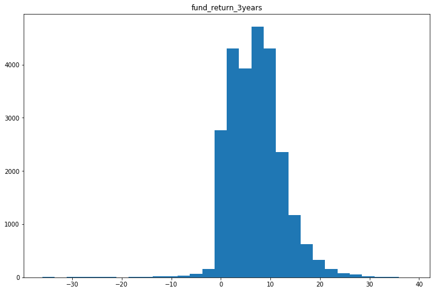

```python
axs = plt.subplots(1, figsize = (12,8))
hdf.cols['fund_return_3years'].hist(bins=30, ax=axs[1])
print("Average in around 7% return")
```

```python
df.select([mean('net_annual_expense_ratio_fund')]).show()
```

```
+----------------------------------+
|avg(net_annual_expense_ratio_fund)|
+----------------------------------+
|                1.1218417101311826|
+----------------------------------+
```

```python
print("Number below 13% is", df3.filter(df3.fund_return_3years < 13).count())
print("Number above 8.5% is", df3.filter(df3.fund_return_3years >= 13).count())
```

```
Number below 13% is 22179
Number above 8.5% is 3012
```

```python
df3 = df3.withColumn('return_binary', F.when(df3['fund_return_3years'] >= 13, 1).otherwise(0))
```

```python
df3_0 = df3[df3.return_binary == 0]
df3_1 = df3[df3.return_binary == 1]
print("Number of non-superior funds are ", df3_0.count())
print("Number of superior funds are ", df3_1.count())
```

```
Number of non-superior funds are  22296
Number of superior funds are  3012
```

Need to calculate What percent to pick at random for df3_0 rows to match length of df3_1

```python
a = df3_1.count()/df3_0.count()
print("need to multiply non-superior funds by a fraction of %0.4f" %a)
```

```
need to multiply non-superior funds by a fraction of 0.1351
```

```python
df3_0_sub = df3_0.sample(False, 0.135, seed=42)
df3_0_sub.count()
```

```
3066
```

Now concatenate both dataframes

```python
df3 = df3_1.union(df3_0_sub)
df3.limit(3)
```

| fund_return_3years | technology | portfolio_stocks | consumer_cyclical | financial_services | healthcare | inv_dummy | size_dummy | return_binary |
| --- | --- | --- | --- | --- | --- | --- | --- | --- |
| 15.39 | 35.3 | 97.06 | 20.2 | 16.12 | 16.52 | 1 | 1 | 1 |
| 13.2 | 33.61 | 99.99 | 29.1 | 0.0 | 8.5 | 0 | 1 | 1 |
| 15.78 | 29.59 | 97.12 | 19.88 | 8.11 | 26.72 | 1 | 1 | 1 |

```python
#shuffle dataframe
from pyspark.sql.functions import rand
df3 = df3.orderBy(rand())
```

## Analyzing NA's

Three Year Fund Return

```python
from pyspark.sql.functions import isnan, when, count, col

df3.select([count(when(isnan(c) | col(c).isNull(), c)).alias(c) for c in df3.columns]).limit(1)
```

| fund_return_3years | technology | portfolio_stocks | consumer_cyclical | financial_services | healthcare | inv_dummy | size_dummy | return_binary |
| --- | --- | --- | --- | --- | --- | --- | --- | --- |
| 23 | 22 | 22 | 22 | 22 | 22 | 0 | 0 | 0 |

```python
df3.where(df3.technology.isNull()).limit(25)
```

| fund_return_3years | technology | portfolio_stocks | consumer_cyclical | financial_services | healthcare | inv_dummy | size_dummy | return_binary |
| --- | --- | --- | --- | --- | --- | --- | --- | --- |
| null | null | null | null | null | null | 0 | 0 | 0 |
| 14.92 | null | null | null | null | null | 1 | 0 | 1 |
| null | null | null | null | null | null | 0 | 0 | 0 |
| null | null | null | null | null | null | 0 | 0 | 0 |
| null | null | null | null | null | null | 0 | 1 | 0 |
| null | null | null | null | null | null | 1 | 1 | 0 |
| null | null | null | null | null | null | 0 | 1 | 0 |
| null | null | null | null | null | null | 0 | 0 | 0 |
| 1.08 | null | null | null | null | null | 0 | 1 | 0 |
| null | null | null | null | null | null | 0 | 1 | 0 |
| null | null | null | null | null | null | 0 | 1 | 0 |
| null | null | null | null | null | null | 1 | 1 | 0 |
| null | null | null | null | null | null | 0 | 1 | 0 |
| 0.17 | null | null | null | null | null | 0 | 0 | 0 |
| 8.14 | null | null | null | null | null | 1 | 0 | 0 |
| 2.14 | null | null | null | null | null | 0 | 1 | 0 |
| 6.28 | null | null | null | null | null | 1 | 1 | 0 |
| 9.25 | null | null | null | null | null | 1 | 0 | 0 |
| null | null | null | null | null | null | 0 | 1 | 0 |
| 5.45 | null | null | null | null | null | 0 | 1 | 0 |

only showing top 20 rows

###### Looks to be significant overlap with NA's in various columns, since the number of NA's is a small portion of our dataframe as well as the significant overlap, it does not make sense to impute the medians. Instead we will just drop all the NA's

```python
print("rows: %d" %(df3.count()))
```

```
rows: 6078
```

```python
df3 = df3.dropna()
print("rows: %d" %(df3.count()))
```

```
rows: 6045
```

### Outliers

```python
df3.columns
```

```
['fund_return_3years',
 'technology',
 'portfolio_stocks',
 'consumer_cyclical',
 'financial_services',
 'healthcare',
 'inv_dummy',
 'size_dummy',
 'return_binary']
```

```python
from handyspark import *
hdf = df3.toHandy()
type(hdf)
```

```
handyspark.sql.dataframe.HandyFrame
```

```python
hdf.show(1)
```

```
+------------------+----------+----------------+-----------------+------------------+----------+---------+----------+-------------+
|fund_return_3years|technology|portfolio_stocks|consumer_cyclical|financial_services|healthcare|inv_dummy|size_dummy|return_binary|
+------------------+----------+----------------+-----------------+------------------+----------+---------+----------+-------------+
|              1.62|       0.0|             0.0|              0.0|               0.0|       0.0|        0|         0|            0|
+------------------+----------+----------------+-----------------+------------------+----------+---------+----------+-------------+
only showing top 1 row
```

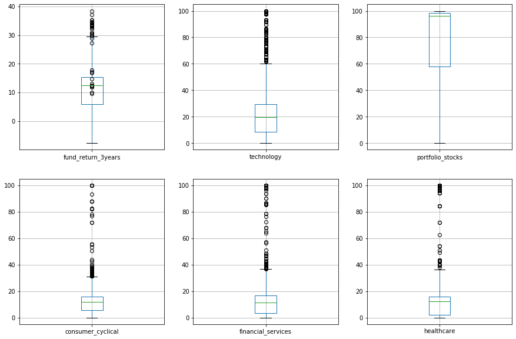

```python
from matplotlib import pyplot as plt
fig, axs = plt.subplots(2, 3, figsize=(15, 10))
hdf.cols['fund_return_3years'].boxplot(ax=axs[0,0])
hdf.cols['technology'].boxplot(ax=axs[0,1])
hdf.cols['portfolio_stocks'].boxplot(ax=axs[0,2])
hdf.cols['consumer_cyclical'].boxplot(ax=axs[1,0])
hdf.cols['financial_services'].boxplot(ax=axs[1,1])
hdf.cols['healthcare'].boxplot(ax=axs[1,2])
```

It would also make sense that an investor may want to invest in a mutual fund that is at least somewhat diversifed, even if it is just a little. Thus we will drop funds that are over 90% weighting in an indivdual sector

```python
df3.describe()
```

| summary | fund_return_3years | technology | portfolio_stocks | consumer_cyclical | financial_services | healthcare | inv_dummy | size_dummy | return_binary |
| --- | --- | --- | --- | --- | --- | --- | --- | --- | --- |
| count | 6045 | 6045 | 6045 | 6045 | 6045 | 6045 | 6045 | 6045 | 6045 |
| mean | 11.124416873449139 | 20.244069478908187 | 74.37221339950372 | 11.33995698924731 | 11.950463192721253 | 11.589631100082707 | 0.49627791563275436 | 0.6004962779156328 | 0.49793217535153017 |
| stddev | 6.683615720911194 | 16.437832913996733 | 37.441640041953605 | 8.523762339428703 | 11.289362667922942 | 11.296376001500017 | 0.5000275063747259 | 0.4898369019013407 | 0.5000370853539773 |
| min | -33.73 | 0.0 | 0.0 | 0.0 | 0.0 | 0.0 | 0 | 0 | 0 |
| max | 38.42 | 100.0 | 100.0 | 100.0 | 100.0 | 100.0 | 1 | 1 | 1 |

```python
a = df3.filter(df3.healthcare >= 90).count()
print("There %d data points in healthcare above 90 percent" %a)
b = df3.filter(df3.technology >= 90).count()
print("There %d data points in technology above 90 percent" %b)
```

```
There 46 data points in healthcare above 90 percent
There 34 data points in technology above 90 percent
```

We will exclude those data points in our analysis

```python
df3 = df3.filter((df3.healthcare <= 90) & (df3.technology <= 90))
print("number of rows is now %d" %df3.count())
```

```
number of rows is now 5965
```

Now limit fund returns range

```python
df3 = df3.filter((df3.fund_return_3years <= 30) &\
                 (df3.fund_return_3years >= -20))
df3.count()
```

```
5944
```

### Scale/Normalize

```python
df3.describe()
```

| summary | fund_return_3years | technology | portfolio_stocks | consumer_cyclical | financial_services | healthcare | inv_dummy | size_dummy | return_binary |
| --- | --- | --- | --- | --- | --- | --- | --- | --- | --- |
| count | 5944 | 5944 | 5944 | 5944 | 5944 | 5944 | 5944 | 5944 | 5944 |
| mean | 10.987567294751008 | 19.8671467025572 | 74.12265477792728 | 11.471130551816957 | 12.131238223418576 | 10.996223082099595 | 0.49125168236877526 | 0.5960632570659489 | 0.4909152086137281 |
| stddev | 6.480604215528919 | 15.31312809132923 | 37.609276694355486 | 8.476219288178202 | 11.295775620843344 | 8.392767084923728 | 0.4999655191683292 | 0.49072636383436485 | 0.4999595173356013 |
| min | -17.91 | 0.0 | 0.0 | 0.0 | 0.0 | 0.0 | 0 | 0 | 0 |
| max | 29.71 | 89.63 | 100.0 | 100.0 | 100.0 | 84.56 | 1 | 1 | 1 |

```python
import copy
from pyspark.sql.types import LongType

_schema = copy.deepcopy(df3.schema)
_schema.add('id_col', LongType(), False) # modified inplace
_df3 = df3.rdd.zipWithIndex().map(lambda l: list(l[0]) + [l[1]]).toDF(_schema)
```

creating a Y to hold return_binary so I can merge it back latter

```python
Y = df3.select('return_binary', 'fund_return_3years')
Y.limit(5)
```

| return_binary | fund_return_3years |
| --- | --- |
| 0 | 1.62 |
| 0 | 6.61 |
| 1 | 14.37 |
| 0 | 2.31 |
| 1 | 15.88 |

```python
df3 = df3.drop('fund_return_3years', 'inv_dummy', 'size_dummy')
df3.limit(2)
```

| technology | portfolio_stocks | consumer_cyclical | financial_services | healthcare | return_binary |
| --- | --- | --- | --- | --- | --- |
| 0.0 | 0.0 | 0.0 | 0.0 | 0.0 | 0 |
| 13.12 | 0.91 | 0.0 | 16.31 | 34.62 | 0 |

When looking at all the variables we can see the value ranges are all fairly different. We must normalize all the values.

```python
from pyspark.ml.feature import MinMaxScaler
from pyspark.ml.feature import VectorAssembler
```

```python
df3.limit(3)
```

| technology | portfolio_stocks | consumer_cyclical | financial_services | healthcare | return_binary |
| --- | --- | --- | --- | --- | --- |
| 0.0 | 0.0 | 0.0 | 0.0 | 0.0 | 0 |
| 13.12 | 0.91 | 0.0 | 16.31 | 34.62 | 0 |
| 16.56 | 95.25 | 9.22 | 21.27 | 19.82 | 1 |

```python
from pyspark.ml.feature import VectorAssembler
vecAssembler = VectorAssembler(inputCols=['technology', 'portfolio_stocks', 'consumer_cyclical',
                                          'financial_services', 'healthcare'], outputCol="features")
stream_df = vecAssembler.transform(df3)
```

Need to create a vector of our features

```python
stream_df.limit(5)
```

| technology | portfolio_stocks | consumer_cyclical | financial_services | healthcare | return_binary | features |
| --- | --- | --- | --- | --- | --- | --- |
| 0.0 | 0.0 | 0.0 | 0.0 | 0.0 | 0 | (5,[],[]) |
| 13.12 | 0.91 | 0.0 | 16.31 | 34.62 | 0 | [13.12,0.91,0.0,1... |
| 16.56 | 95.25 | 9.22 | 21.27 | 19.82 | 1 | [16.56,95.25,9.22... |
| 0.0 | 0.0 | 0.0 | 0.0 | 0.0 | 0 | (5,[],[]) |
| 37.82 | 98.38 | 14.9 | 8.57 | 16.27 | 1 | [37.82,98.38,14.9... |

Now we need to create a column of our scaled features

```python
from pyspark.ml.feature import MinMaxScaler
scaler = MinMaxScaler(inputCol="features", outputCol="scaledFeatures")
scaledData = scaler.fit((stream_df)).transform(stream_df)
scaledData.limit(5)
```

| technology | portfolio_stocks | consumer_cyclical | financial_services | healthcare | return_binary | features | scaledFeatures |
| --- | --- | --- | --- | --- | --- | --- | --- |
| 0.0 | 0.0 | 0.0 | 0.0 | 0.0 | 0 | (5,[],[]) | (5,[],[]) |
| 13.12 | 0.91 | 0.0 | 16.31 | 34.62 | 0 | [13.12,0.91,0.0,1... | [0.14637956041503... |
| 16.56 | 95.25 | 9.22 | 21.27 | 19.82 | 1 | [16.56,95.25,9.22... | [0.18475956710922... |
| 0.0 | 0.0 | 0.0 | 0.0 | 0.0 | 0 | (5,[],[]) | (5,[],[]) |
| 37.82 | 98.38 | 14.9 | 8.57 | 16.27 | 1 | [37.82,98.38,14.9... | [0.42195693406225... |

```python
column_names = ['technology', 'portfolio_stocks', 'consumer_cyclical', 'financial_services', 'healthcare']
scaled = scaledData.rdd.map(lambda x:[float(y) for y in x['scaledFeatures']]).toDF(column_names)
```

To see what the scaled features look like

```python
scaled
```

| technology | portfolio_stocks | consumer_cyclical | financial_services | healthcare |
| --- | --- | --- | --- | --- |
| 0.0 | 0.0 | 0.0 | 0.0 | 0.0 |
| 0.1463795604150396 | 0.0091 | 0.0 | 0.1631 | 0.4094134342478713 |
| 0.1847595671092268 | 0.9525 | 0.0922 | 0.2127 | 0.23438978240302744 |
| 0.0 | 0.0 | 0.0 | 0.0 | 0.0 |
| 0.42195693406225593 | 0.9838 | 0.149 | 0.0857 | 0.1924077578051088 |
| 0.3874818699096284 | 0.9752 | 0.0835 | 0.0911 | 0.31504257332071905 |
| 0.11067722860649336 | 0.9368000000000001 | 0.049 | 0.2386 | 0.1840113528855251 |
| 0.26799062813790026 | 0.9993000000000001 | 0.11810000000000001 | 0.1437 | 0.2317880794701987 |
| 0.5328573022425527 | 0.9591 | 0.1429 | 0.0454 | 0.21144749290444653 |
| 0.0 | 0.0 | 0.0 | 0.0 | 0.0 |
| 0.39183309159879504 | 0.9665 | 0.20010000000000003 | 0.1075 | 0.19749290444654682 |
| 0.17806537989512441 | 0.9901000000000001 | 0.1593 | 0.1954 | 0.174077578051088 |
| 0.36349436572576144 | 0.9956 | 0.17670000000000002 | 0.16399999999999998 | 0.16686376537369915 |
| 0.17851165904273122 | 0.5815 | 0.1908 | 0.1412 | 0.1403736991485336 |
| 0.03904942541559746 | 0.9706 | 0.1255 | 0.153 | 0.15208136234626302 |
| 0.11034251924578825 | 0.8606 | 0.3778 | 0.059000000000000004 | 0.0 |
| 0.0 | 0.0 | 0.0 | 0.0 | 0.0 |
| 0.2650898136784559 | 0.9993000000000001 | 0.17079999999999998 | 0.1023 | 0.13410596026490065 |
| 0.3498828517237532 | 1.0 | 0.1193 | 0.044800000000000006 | 0.2619441816461684 |
| 0.15340845698984715 | 0.9569 | 0.1051 | 0.1819 | 0.12464522232734153 |

only showing top 20 rows

Now drop unncessary columns for scaledData

```python
scaledData = scaledData.drop('technology',
                'portfolio_stocks',
                'consumer_cyclical',
                'financial_services',
                'healthcare',
                'features')
scaledData.limit(5)
```

| return_binary | scaledFeatures |
| --- | --- |
| 0 | (5,[],[]) |
| 0 | [0.14637956041503... |
| 1 | [0.18475956710922... |
| 0 | (5,[],[]) |
| 1 | [0.42195693406225... |

Assign labels for spark ml

```python
scaledData = scaledData.withColumnRenamed('return_binary', 'label')
scaledData = scaledData.withColumnRenamed('scaledFeatures', 'features')
```

### Training and Test Data

```python
train, test = scaledData.randomSplit([0.7, 0.3], seed = 42)
```

```python
train.limit(10)
```

| label | features |
| --- | --- |
| 0 | (5,[],[]) |
| 0 | (5,[],[]) |
| 0 | (5,[],[]) |
| 0 | (5,[],[]) |
| 0 | (5,[1],[0.0040999... |
| 0 | [0.11034251924578... |
| 0 | [0.15340845698984... |
| 0 | [0.17851165904273... |
| 0 | [0.18710253263416... |
| 1 | [0.16668526163115... |

```python
a = train.count()/(test.count() + train.count())
a
```

```
0.6921265141318977
```

## SVM

###### Important Note

sklearn uses C to scale the loss (error) term. I.e., use a small regParam or big C to reduce regularization strength; use a big regParam or small C to increase regularization. These are (scaled) inverses of each other. The easiest way to get the best results for each implementation is to tune each separately.

```python
from pyspark.ml.classification import LinearSVC
lsvc = LinearSVC(maxIter=10, regParam=0.1)
```

```python
lsvcModel = lsvc.fit(train)
```

```python
lsvcModel
```

```
LinearSVCModel: uid=LinearSVC_f8b3b1285267, numClasses=2, numFeatures=5
```

```python
# Print the coefficients and intercept for linearsSVC
print("Coefficients: " + str(lsvcModel.coefficients))
print("Intercept: " + str(lsvcModel.intercept))
```

```
Coefficients: [4.789486180595648,0.94515843503628,2.827736562025021,-2.3660728151213752,3.311002532333253]
Intercept: -2.451125431624504
```

```python
from pyspark.mllib.linalg import Vectors
predictions = lsvcModel.transform(test)
```

```python
from pyspark.ml.evaluation import BinaryClassificationEvaluator
evaluator = BinaryClassificationEvaluator()
print("Our ROC Score is:", evaluator.evaluate(predictions))
```

```
Our ROC Score is: 0.9125118249054006
```

```python
from pyspark.ml.evaluation import MulticlassClassificationEvaluator
evals = MulticlassClassificationEvaluator(metricName="accuracy")
accuracy = evals.evaluate(predictions)
evals = MulticlassClassificationEvaluator(metricName="weightedPrecision")
precision = evals.evaluate(predictions)
evals = MulticlassClassificationEvaluator(metricName="weightedRecall")
recall = evals.evaluate(predictions)
print("SVM accuracy:", accuracy)
print("SVM precision:", precision)
print("SVM Recall:", recall)
print("Our ROC Score is:", evaluator.evaluate(predictions))
```

```
SVM accuracy: 0.8546448087431694
SVM precision: 0.8551175494657327
SVM Recall: 0.8546448087431694
Our ROC Score is: 0.9125118249054006
```

```python
from pyspark.ml.classification import LinearSVC
clf = LinearSVC(maxIter=10, regParam=0.01)
clfModel = clf.fit(train)
```

```python
predictions = clfModel.transform(test)
```

```python
print("Metrics for SVM with regParma = 0.5")
print("Our ROC Score is:", evaluator.evaluate(predictions))
evals = MulticlassClassificationEvaluator(metricName="accuracy")
accuracy = evals.evaluate(predictions)
evals = MulticlassClassificationEvaluator(metricName="weightedPrecision")
precision = evals.evaluate(predictions)
evals = MulticlassClassificationEvaluator(metricName="weightedRecall")
recall = evals.evaluate(predictions)
print("SVM accuracy:", accuracy)
print("SVM precision:", precision)
print("SVM Recall:", recall)
```

[output not shown]

### Two Impactful Features for SVM

```python
df2 = df3.drop('portfolio_stocks', 'financial_services', 'healthcare')
df2.limit(3)
```

| technology | consumer_cyclical | return_binary |
| --- | --- | --- |
| 0.0 | 0.0 | 0 |
| 13.12 | 0.0 | 0 |
| 16.56 | 9.22 | 1 |

```python
from pyspark.ml.feature import VectorAssembler
vecAssembler = VectorAssembler(inputCols=['technology', 'consumer_cyclical'], outputCol="features")
stream_df = vecAssembler.transform(df2)
stream_df.limit(5)
```

| technology | consumer_cyclical | return_binary | features |
| --- | --- | --- | --- |
| 0.0 | 0.0 | 0 | (2,[],[]) |
| 13.12 | 0.0 | 0 | [13.12,0.0] |
| 16.56 | 9.22 | 1 | [16.56,9.22] |
| 0.0 | 0.0 | 0 | (2,[],[]) |
| 37.82 | 14.9 | 1 | [37.82,14.9] |

```python
scaler = MinMaxScaler(inputCol="features", outputCol="scaledFeatures")
scaledData = scaler.fit((stream_df)).transform(stream_df)
scaledData.limit(5)
```

| technology | consumer_cyclical | return_binary | features | scaledFeatures |
| --- | --- | --- | --- | --- |
| 0.0 | 0.0 | 0 | (2,[],[]) | (2,[],[]) |
| 13.12 | 0.0 | 0 | [13.12,0.0] | [0.14637956041503... |
| 16.56 | 9.22 | 1 | [16.56,9.22] | [0.18475956710922... |
| 0.0 | 0.0 | 0 | (2,[],[]) | (2,[],[]) |
| 37.82 | 14.9 | 1 | [37.82,14.9] | [0.42195693406225... |

```python
scaledData = scaledData.drop('technology', 'consumer_cyclical', 'features')
scaledData.limit(5)
```

| return_binary | scaledFeatures |
| --- | --- |
| 0 | (2,[],[]) |
| 0 | [0.14637956041503... |
| 1 | [0.18475956710922... |
| 0 | (2,[],[]) |
| 1 | [0.42195693406225... |

```python
scaledData = scaledData.withColumnRenamed('return_binary', 'label')
scaledData = scaledData.withColumnRenamed('scaledFeatures', 'features')
```

Train and Test Data

```python
train, test = scaledData.randomSplit([0.7, 0.3], seed = 42)
```

SVM

```python
model = LinearSVC(maxIter=10, regParam=0.01 )
modelfit = model.fit(train)
predictions = modelfit.transform(test)
```

```python
print("Metrics for SVM with regParma = 0.9")
print("Our ROC Score is:", evaluator.evaluate(predictions))
evals = MulticlassClassificationEvaluator(metricName="accuracy")
accuracy = evals.evaluate(predictions)
evals = MulticlassClassificationEvaluator(metricName="weightedPrecision")
precision = evals.evaluate(predictions)
evals = MulticlassClassificationEvaluator(metricName="weightedRecall")
recall = evals.evaluate(predictions)
print("SVM accuracy:", accuracy)
print("SVM precision:", precision)
print("SVM Recall:", recall)
```

[output not shown]